# Homework 4

The last parameter, `sigma`, is the residual standard deviation of sales, aka the variability in the data not represented in the model. The estimate is 1.02, with a 95% CI of [0.95, 1.08], meaning that there is a good amount of variability in the data, but the model can account for most of the variability.

5. **Summary**: On average, stores have less sales from food than from coffee, but this difference becomes less significant if stores have more conscientious managers. Conscientiousness has a meaningful interaction with food sales, since it boosts the effect of food sales on overall sales. Neuroticism has some effect on sales, but these effects are weak or uncertain. Stores have a lot of variability on baseline sales and food sales, but they have a weak correlation, so whether there is a relationship between both types of sales or not isn’t certain. The model is well-specified, since the sampling of the data converges well, and the residual variability is low ($\sigma = 1.02$), meaning that the model explains the data well.
6. **Diagnostics**:

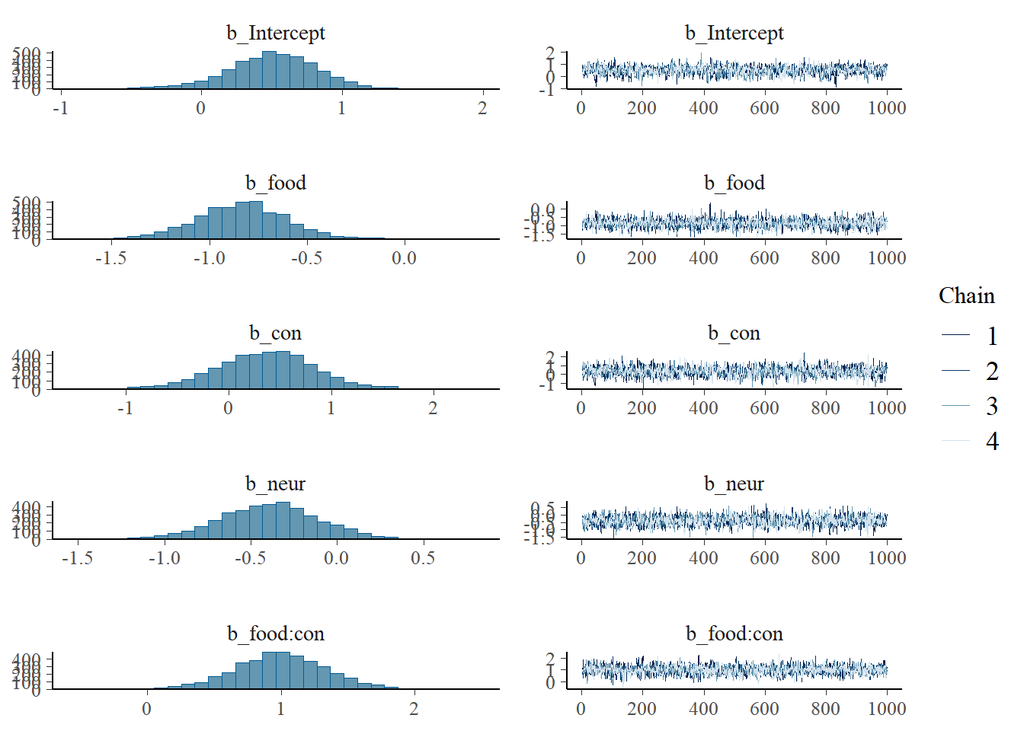

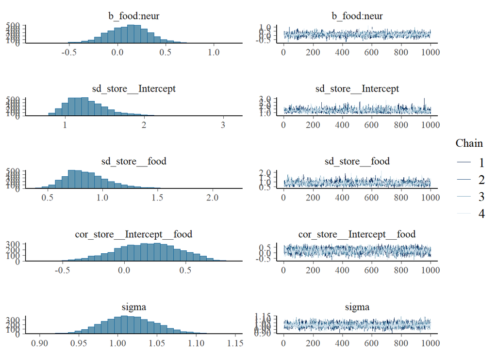

```r
plot(fit)
```